# Bayesian Models

Author

Sky Taylor

## Describe and Summarise Dataset

The dataset contains the variables Gender, Mood Disorder, Interoception, and Total BDI-II score across 240 participants.

Table 1 provides information on the dispersion of interoception and BDI-II scores. Table 2 shows summary statistics for interoception and BDI-II scores grouped by gender and mood disorder diagnosis.

Table 1: Descriptive statistics.

|  | mean | sd | min | max | range | se |
| --- | --- | --- | --- | --- | --- | --- |
| Interoception | 15.24 | 2.89 | 0.97 | 21 | 20.03 | 0.19 |
| BDI2_Total | 15.96 | 12.06 | 0.00 | 52 | 52.00 | 0.78 |

Table 2: Summary statistics grouped by gender and mood disorder diagnosis.

| Gender | MoodDisorder | Interoception Mean | Interoception SD | BDI-II Mean | BDI-II SD | n | Percentage(%) |
| --- | --- | --- | --- | --- | --- | --- | --- |
| Female | FALSE | 15.56 | 3.24 | 15.16 | 11.15 | 109 | 45.42 |
| Female | TRUE | 14.97 | 2.28 | 23.42 | 14.60 | 24 | 10.00 |
| Male | FALSE | 15.09 | 2.55 | 12.88 | 9.92 | 89 | 37.08 |
| Male | TRUE | 14.48 | 2.88 | 26.17 | 14.63 | 18 | 7.50 |

## Bayesian Correlation

Figure 1 shows a scatterplot of the BDI-II and Interoception scores, indicating a weak negative correlation.

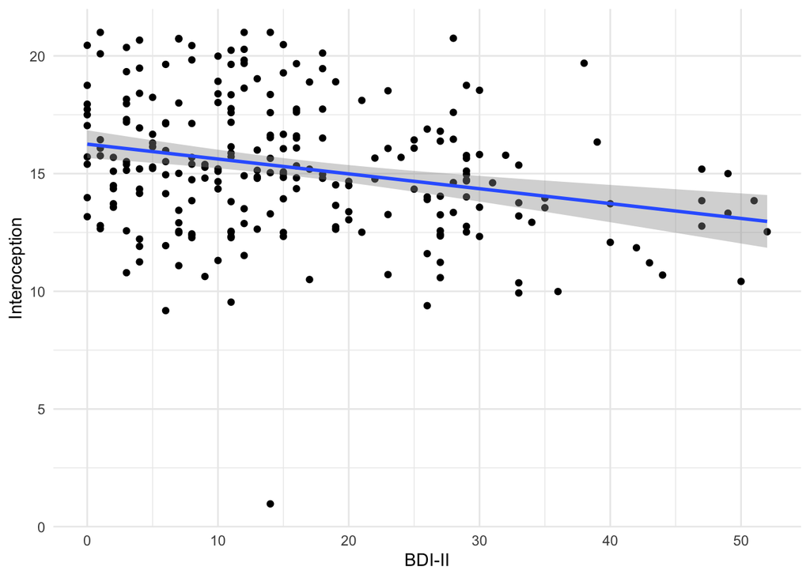

Figure 1: Scatterplot of BDI-II and Interoception scores.

Default priors from the BayesFactor package *correlationBF()* function were used, with the *rscale* parameter being set to medium. The Bayes Factor of $\text{BF}_{10}=647.54$ is extreme evidence for a correlation.

The Markov Chain Monte Carlo (MCMC) sampling technique was used with 500 iterations to approximate the posterior distribution. Upon inspection of the posterior trace plots Figure 2, the trace appears stationary and random across iterations.

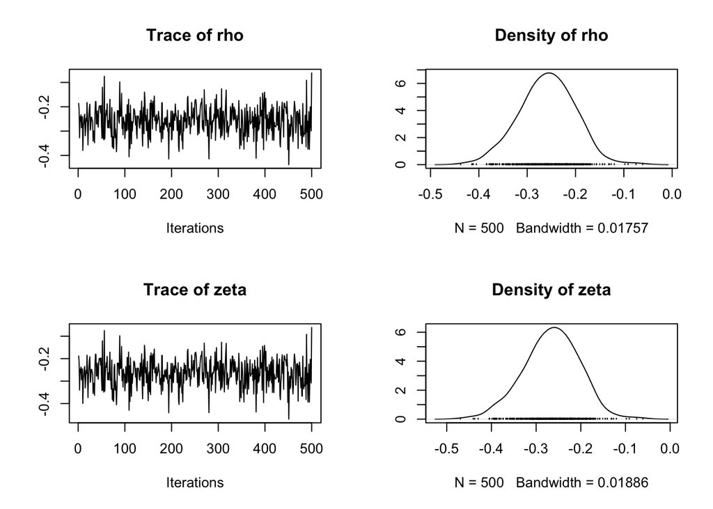

Figure 2: MCMC diagnostic plots.

Figure 3 shows the prior and posterior distributions, showing how we should adjust our beliefs given the data. The posterior distribution indicates that a weak negative correlation between total BDI-II and interoception is highly likely. Table 3 reports indices to describe the posterior distribution and further indicates the existence of a small negative correlation (*r* = -.26, 95% CI [-.37, -.15]), with a probability of direction of 1 which suggests that a negative correlation certainly exists.

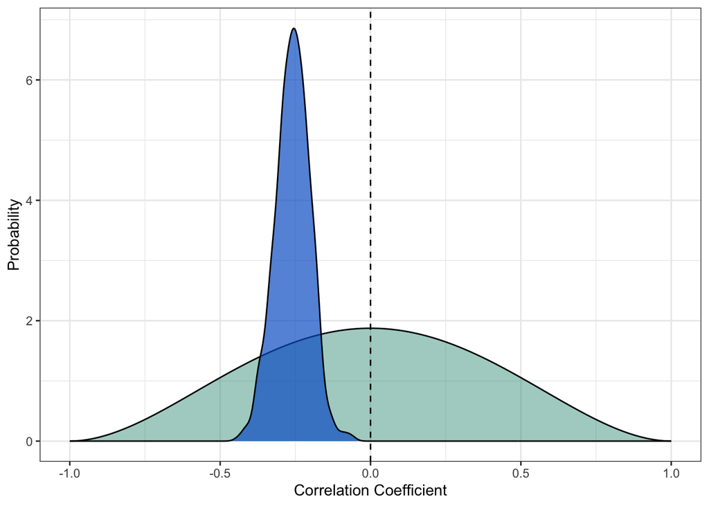

Figure 3: Correlation prior and posterior distributions.

Table 3: Indices of centrality, uncertainty, and effect direction for the correlation posterior.

| Median | MAD | CI_low | CI_high | PD |
| --- | --- | --- | --- | --- |
| -0.26 | 0.06 | -0.37 | -0.15 | 1 |

*Note*. MAD = Median Absolute Deviation, CI = 95% Credible Interval computed using equal-tailed intervals, PD = Probability of Direction.

## Bayesian *t*-Test

Table 4: Indices of centrality, uncertainty, and effect direction for the t-test posterior.

| Parameter | Median | CI_low | CI_high | pd | BF |
| --- | --- | --- | --- | --- | --- |
| Difference | 0.53 | -0.39 | 1.44 | 0.87 | 0.35 |

## Bayesian Linear Model

A Bayesian linear model is used to test the hypothesis that there is a relationship between BDI-II scores and interoception scores that is modulated by gender.

To inform priors, the range of data is visualised in Figure 4 which shows that BDI-II scores cover a wide range. A normal distribution centred around the mean BDI-II score (*M* = 15.96) with a wide distribution of 10 times the standard deviation (*SD* = 12.06) was used to set a weakly informative prior distribution for the intercept (Normal(15.96, 120.60)). Assuming the intercept is the mean of BDI-II, values of interoception slopes smaller than -1 and larger than 3 are quite extreme and hence the coefficient prior, which centres around 0 to reflect the null hypothesis, gives low plausibility to values outside of this range (Normal(0, 5)). Default priors were used for the effect of gender and the interaction term.

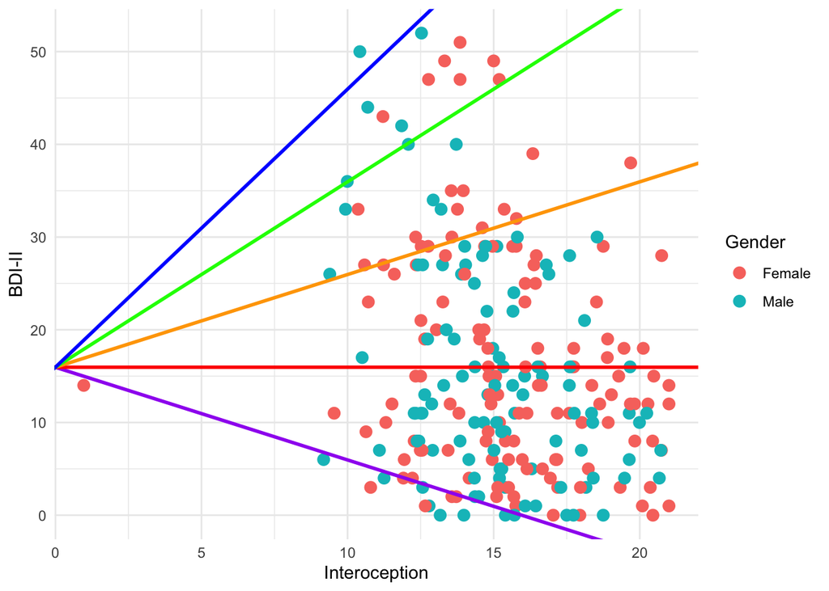

Figure 4: Scatterplot of BDI-II and interoception grouped by gender.

The MCMC sampling technique was used with 1000 iterations to approximate the posterior distribution. Upon inspection of the posterior trace plots (Figure 5), the trace appears stationary and random across iterations with no evidence of autocorrelation between successive samples.

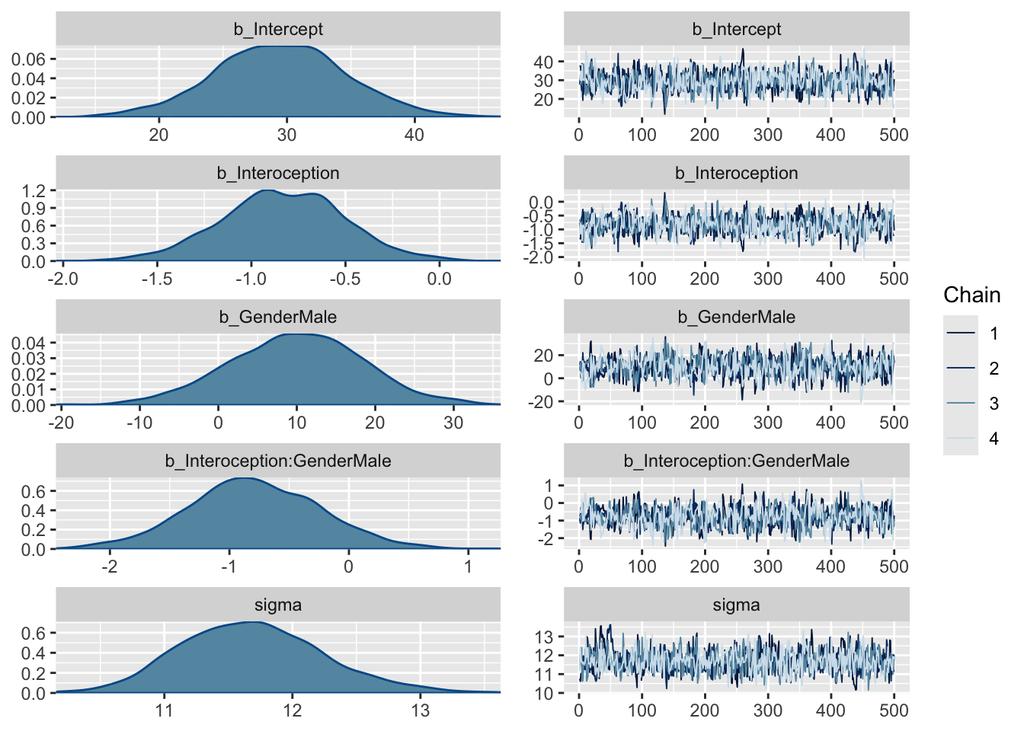

Figure 5: MCMC diagnostic plots.

Table 5: Indices of centrality, uncertainty, and effect direction for the linear model posterior.

| Parameter | Mean | CI_low | CI_high | pd | Rhat | ESS |
| --- | --- | --- | --- | --- | --- | --- |
| b_Intercept | 29.49 | 19.01 | 39.66 | 1.00 | 1 | 773.66 |
| b_Interoception | -0.83 | -1.49 | -0.19 | 0.99 | 1 | 779.24 |
| b_GenderMale | 9.95 | -6.87 | 26.73 | 0.88 | 1 | 728.39 |
| b_Interoception:GenderMale | -0.79 | -1.87 | 0.30 | 0.92 | 1 | 732.77 |
| sigma | 11.69 | 10.68 | 12.88 | 1.00 | 1 | 1001.25 |

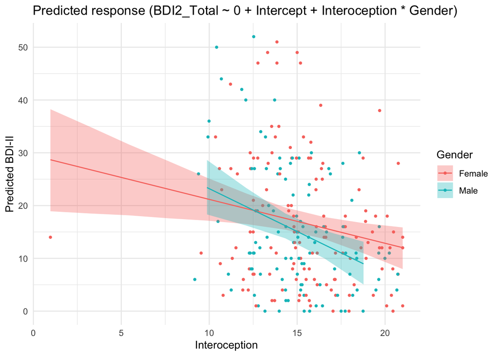

Figure 6: Predicted relationship based on the Bayesian linear model.